# act_report

## ACT REPORT

### There are some interesting findings I made during the insight and visualization aspect of this project

### - 1. What dog type is most retweeted and most favorited?

##### For the average retweet count by dog type I found out 'doggo' is slightly higher than 'puppo' in general, so if you want your dog image to get more retweets from weratedogs you should look forward to getting a 'puppo' or 'doggo' for more engagement.

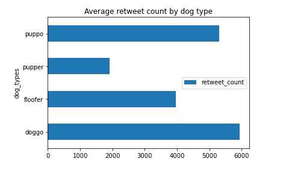

##### For the average favorite count by dog type I found out 'puppo' is slightly higher than 'doggo' in general, so if you want your dog image to get more likes from weratedogs you should look forward to getting a 'puppo' or 'doggo' for more engagement.

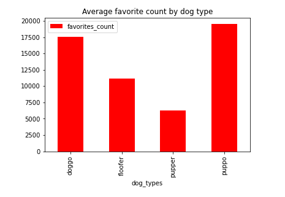

### 2. Total Tweets made each Month

##### this was an interesting part of my insight and visualization, I first had to change the timestamp column to a datetime datatype, then I had to prepare the timestamp column for visualization, the column had both date and time joined in the column so I had to remove the time and focus only on the date. I then queried the date using group with the total sum of tweet each month. then I used seaborn pointplot to plot the graph.

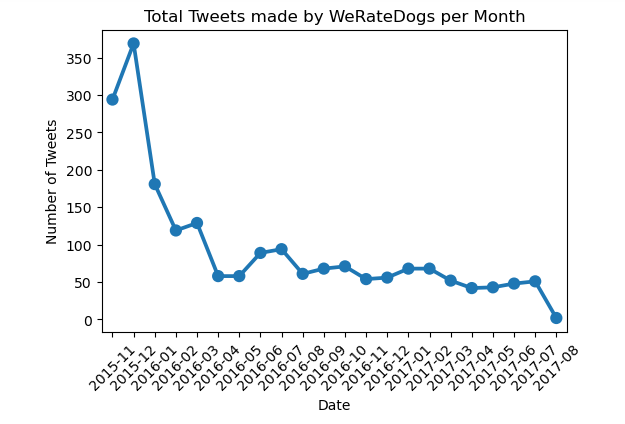

##### from the visualization the rate at which weratedogs post tweets each month have been dropping drastically... and I wonder why.

### 3. Top 3 Common Dog Breeds

##### I had to check the dog breed colum value counts to see how many time each dog breed appear in the dataset,

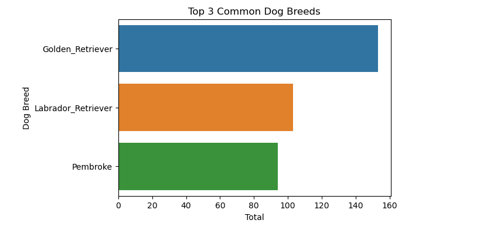

##### Golden Retriever, Labrador_Retriever and Pembroke respectivetly are the most common breed predicted based on the images per tweet seen on weratedogs